# Lab 7: Functions & Fish

Author

Danial Shaikh

```r
library(ggplot2)
library(dplyr)
library(patchwork)
```

# **2 Part One: Summaries and Plots (Midterm Review)**

## **2.1 Summarizing Missing Data**

The measurements of each fish captured were taken by a Biologist on a raft. This lack of “laboratory setting” opens the door to the possibility of measurement errors.

- What variable(s) have missing values present?
- How many observations within each variable have missing values?

```r
# Load the data
fish_data <- read.csv("https://atheobold.github.io/stat-331/7_functions/Lab/BlackfootFish.csv")

fish_data %>%
  summarize(across(everything(), ~ sum(is.na(.))))
```

```
  trip mark length weight year section species
1    0    0      0   1796    0       0       0
```

## **2.2 Visualizing Missing Data**

Create a thoughtful visualization exploring the frequency of missing values across the different years, sections, and trips.

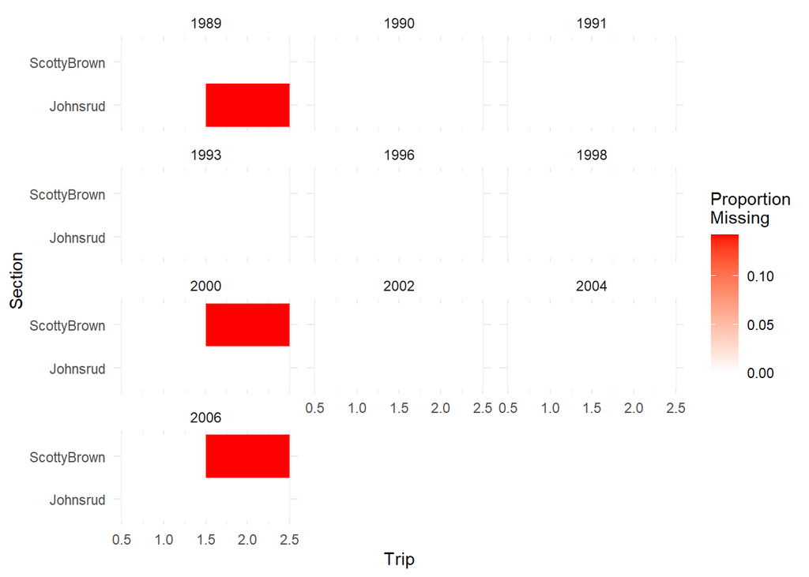

```r
# Create a new data frame to count the number of missing values for each combination of year, section, and trip
missing <- is.na(fish_data)
missing_prop <- apply(missing, 1, mean)
missing_prop_df <- data.frame(trip = fish_data$trip, section = fish_data$section, year = fish_data$year, prop_missing = missing_prop)

# heatmap
ggplot(missing_prop_df, aes(trip, section, fill = prop_missing)) +
  geom_tile() +
  scale_fill_gradient(low = "white", high = "red") +
  facet_wrap(~ year, ncol = 3) +
  xlab("Trip") +
  ylab("Section") +
  labs(fill = "Proportion\nMissing") +
  theme_minimal()
```

# **3 Part Two: Adjusting the Data (Function Writing)**

The following `R` code would carry out this rescaling procedure for the `length` and `weight` columns of the data:

```r
BlackfootFish <- BlackfootFish |>
  mutate(length = (length - min(length, na.rm = TRUE)) /
           (max(length, na.rm = TRUE) - min(length)),
         weight = (weight - min(weight, na.rm = TRUE)) /
           (max(weight, na.rm = TRUE) - min(length, na.rm = TRUE))
         )
```

[output not shown]

## **3.1 Writing a Function**

Let’s transform the repeated process above into a `rescale_01()` function.

- The function should take a single vector as its input.
- The function should return the rescaled vector.

```r
rescale_01 <- function(x){
  if (!is.numeric(x)) {
    stop("This is a non numeric vector, enter a numeric vector")
  }
  if (length(x) <= 1) {
    stop("Input vector size must be greater than 1.")
  }
  (x - min(x, na.rm = TRUE)) / (max(x, na.rm = TRUE) - min(x, na.rm = TRUE))
}
```

## **3.2 Adding Stops**

Now, let’s incorporate some checks into your function! Modify your previous code to create the following checks:

- the function should stop if the input vector is not numeric
- the function should stop if the length of the vector is not greater than 1